# Multivariate Analysis on Metabolites

Brittany Alexandra

Wednesday 15 March 2023`

# Introduction

This is an exploratory analysis of metabolites affected by whey consumption utilizing a relatively clean dataset. As someone with a love for biology and the gym, this was a fascinating dataset to analyse, and a great test on my understanding of multivariate analysis techniques.

# Findings

Each of these Amino Acids participate in metabolic pathways. Therefore, understanding how they are influenced provides a foundation for further investigation in how to enhance, or reduce these Amino Acids and their consequent biological consequences.

For example;

- **L.Leucine** is renowned for its ability to activate mTOR signaling, and is a central regulator of muscle protein synthesis. It’s involvement in this critical pathway underscores its significance in the context of muscle growth and repair.
- **L.Tryptophan** serves as a precursor to serotonin, which is a neurotransmitter crucial for mood regulation. L.Tryptophan wields influence over our emotional well-being, and understanding how its levels respond to whey protein consumption opens a window into potential therapeutic avenues aimed at elevating serotonin levels for mood enhancement.
- **L.Lysine** is involved in collagen formation, calcium absorption, and the synthesis of carnitine, a molecule crucial for energy production.Therefore, monitoring L.Lysine levels in response to whey protein consumption can help understand its impact on skin health, bone health, and energy metabolism.

# Concerns

1. This is a snapshot of data and therefore does not capture the inherent individual variability
2. This snapshot of data was done in an isolated environment, and would therefore be inaccurate to generalize to a wider population. Further tests with a more diverse sample size representative of the population would be required to generalise these results.
3. Limited time-frame thereby not accounting for variability into metabolism and digestion over longer periods of time i.e. >24 hours.

# Background

The “metab-selected.csv” file presents an intriguing snapshot from a study on whey protein beverages and their impact on blood metabolites (as detailed in Joblin-Mills et al., Frontiers in Clinical Diabetes).

It captures the dynamic response of 52 significant metabolites to three beverage variants; a water-based control, a standard whey protein drink, and a double-concentration whey variant.

These were tracked over key time intervals post-consumption. This dataset, with its log-transformed values, offers a window into understanding how dietary changes can distinctly alter metabolic profiles.

# Statistical Analysis

```r
# Lets take a look at the data to get an understanding of it
data <- read_csv("~/Desktop/metab-selected.csv")
head(data)
```

```
## # A tibble: 6 × 55
##   Participant Meal   Time X4.aminobutanoate L.Leucine Uridine
##   <chr>       <chr> <dbl>             <dbl>     <dbl>   <dbl>
## 1 SC4203      B       120              8.38      15.5    10.2
## 2 SC4203      B       240              8.46      14.9    10.8
## 3 DL4204      A        30              8.60      14.9    11.5
## 4 SC4203      C       120              8.64      16.2    10.1
## 5 SC4203      A       120              8.65      14.9    11.3
## 6 SC4203      C         0              8.67      14.7    11.1
## # ℹ 49 more variables: X1.Methylpyrrolinium <dbl>, Acetylcholine <dbl>,
## #   L.Proline <dbl>, Succinic.acid <dbl>, Uric.acid <dbl>, L.Arginine <dbl>,
## #   L.Tryptophan <dbl>, X2.3.4.5.6.7.Hexahydroxyheptanoic.acid <dbl>,
## #   X1.Methylnicotinamide <dbl>, X3.Hexenedioic.acid <dbl>,
## #   L.Phenylalanine <dbl>, cis.Aconitic.acid <dbl>, Citric.acid <dbl>,
## #   Isocitric.acid <dbl>, Aspartyl.L.proline <dbl>, Pyroglutamic.acid <dbl>,
## #   L.Glutamic.acid <dbl>, L.Lysine <dbl>, L.Methionine <dbl>, …
```

## 1. Lets reduce the dimensional of our data to understand the structure and covariance of metabolites

[figure not shown]

```r
#Clean data
data<-data[,-c(1:3)]
data<-log(data)
missing<-apply(is.na(data),2 , sum)
data<-data[,missing==0]
sd<-apply(data, 2, sd)
data<-data[,sd>0.001]


#Data matrix for simple, effective, but ugly plot
PCA<-prcomp(data, center=T, scale = T)
# plot(PCA)

# Limit the data to the first 8 principal components to not overwhelm 8 axis
variance_explained <- PCA$sdev^2 / sum(PCA$sdev^2)  # Proportion of variance explained by each PC

# Create a dataframe with Principal Component and Variance Explained
variance_df <- data.frame(
  PrincipalComponent = 1:length(variance_explained),
  VarianceExplained = variance_explained
)

variance_df <- variance_df[1:8,]

# Create a bar chart for the first 6 principal components
gg_var_plot <- ggplot(variance_df, aes(x = PrincipalComponent, y = VarianceExplained)) +
  geom_bar(stat = "identity", fill = "steelblue") +
  theme_minimal() +
  labs(title = "Variance Explained by the First 6 Principal Components",
       subtitle = "Plot 1",
       x = "Principal Component",
       y = "Proportion of Variance Explained") +
  geom_text(aes(label = scales::percent(VarianceExplained, accuracy = 1)), vjust = -0.5)

# Print the bar chart
print(gg_var_plot)
```

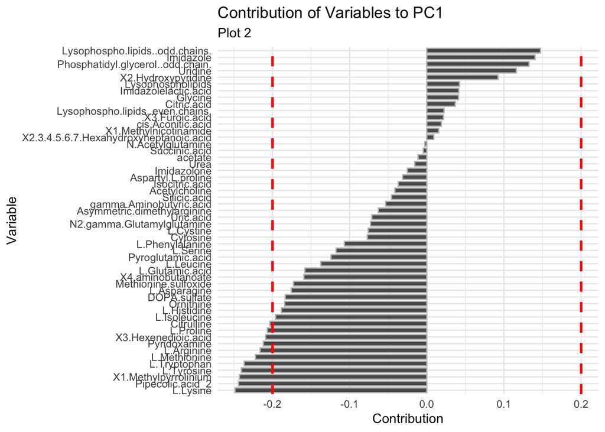

```r
# Assuming PCA is your PCA result object
loadings <- as.data.frame(PCA$rotation[, 1])  # Extract loadings for PC1
names(loadings) <- "Contribution"
loadings$Variable <- rownames(loadings)

# Create the bar plot
ggplot(loadings, aes(x = reorder(Variable, Contribution), y = Contribution)) +
  geom_bar(stat = "identity", col = "gray", position = position_dodge(width = 0.7), width = 0.7) +
  coord_flip() +
  theme_minimal() +
  labs(title = "Contribution of Variables to PC1",
       subtitle = "Plot 2",
       x = "Variable",
       y = "Contribution") +
  geom_hline(yintercept = c(-0.2, 0.2), linetype = "dashed", color = c("red", "red"), size = 1)
```

```r
  #annotate("text", x = 1.5, y = 0.25, label = "Metabolites beyond -0.2 and 0.2 contribute significantly", color = "black", size = 4)
```

Overall, we can understand a large amount of variation from the first Principal Component (Plot 1). (PC summarizes the core differences or similarities within the data). This gives us a benchmark for investigating dominant underlying factors that are influencing the observed measurements.

Metabolites beyond -0.2 and 0.2 contribute significantly to the variance (Plot 2).

For further studies, isolating the top 10 metabolites and see how they react to whey consumption and the effects on the human body would be interesting.

**Notes**

28.6% of the variability in blood metabolites following Whey Protein consumption is accounted for by the first principal component, and 9.5% for the second PC.

What does this mean? Well, in PCA, each principal component represents a linear combination of the original variables. The first PC captures the most significant patterns of variation in the data, while the subsequent PCs capture the remaining variability in decreasing order of importance.

As the first principal component explains 28.6% of the total variability, we can say it is responsible for a substantial portion of the patterns observed in the blood metabolites following Whey Protein consumption. This component likely represents the primary factor influencing the changes in metabolite levels.

Similarly, the second principal component accounts for 9.5% of the variability. While it explains less variability compared to the first PC, it still captures a notable proportion of the patterns in the data. The second component likely represents additional factors that contribute to the variability in blood metabolites, possibly representing specific metabolic responses or interactions.

## What variables were signifcantly affected by the meals post whey consumption?

By understanding the variables that have a strong correlation with the first PC score, we can identify the metabolites most significant imapcted by whey consumption are:

```r
# Coefficients and their strength with PC1
coef1 <- round(PCA$rotation[, 1] * PCA$sdev[1], 2)
variable_names <- names(coef1)

coef_table <- data.frame(Variable = variable_names) # Create a data frame with a single "Variable" column
coef_table$Coefficient <- coef1 # Create a new column for the coefficients
sorted_coef_table <- coef_table[order(coef1, decreasing = TRUE), ] # Sort the table based on the coefficients

# Remove the row numbers (index)
rownames(sorted_coef_table) <- NULL

# Create a nice table
kable(sorted_coef_table,
      caption = "Coefficients and Their Strength with PC1",
      align = "c",
      col.names = c("Variable", "Coefficient"),
      format.args = list(big.mark = ",", scientific = FALSE),  # Formatting options
      booktabs = TRUE)
```

Coefficients and Their Strength with PC1

| Variable | Coefficient |
| --- | --- |
| Lysophospho.lipids..odd.chains. | 0.57 |
| Imidazole | 0.54 |
| Phosphatidyl.glycerol..odd.chain. | 0.51 |
| Uridine | 0.45 |
| X2.Hydroxypyridine | 0.36 |
| Imidazolelactic.acid | 0.16 |
| Glycine | 0.16 |
| Lysophospholipids | 0.16 |
| Citric.acid | 0.14 |
| Lysophospho.lipids..even.chains. | 0.09 |
| X3.Furoic.acid | 0.08 |
| cis.Aconitic.acid | 0.07 |
| X1.Methylnicotinamide | 0.06 |
| X2.3.4.5.6.7.Hexahydroxyheptanoic.acid | 0.03 |
| N.Acetylglutamine | -0.01 |
| Succinic.acid | -0.02 |
| acetate | -0.04 |
| Urea | -0.06 |
| Imidazolone | -0.10 |
| Aspartyl.L.proline | -0.12 |
| Isocitric.acid | -0.14 |
| Acetylcholine | -0.16 |
| Silicic.acid | -0.18 |
| gamma.Aminobutyric.acid | -0.21 |
| Asymmetric.dimethylarginine | -0.24 |
| Uric.acid | -0.27 |
| N2.gamma.Glutamylglutamine | -0.28 |
| L.Cystine | -0.29 |
| Cytosine | -0.30 |
| L.Phenylalanine | -0.41 |
| L.Serine | -0.45 |
| Pyroglutamic.acid | -0.48 |
| L.Leucine | -0.53 |
| X4.aminobutanoate | -0.61 |
| L.Glutamic.acid | -0.61 |
| Methionine.sulfoxide | -0.67 |
| L.Asparagine | -0.68 |
| DOPA.sulfate | -0.71 |
| Ornithine | -0.71 |
| L.Histidine | -0.73 |
| L.Isoleucine | -0.76 |
| Citrulline | -0.78 |
| L.Proline | -0.80 |
| X3.Hexenedioic.acid | -0.80 |
| Pyridoxamine | -0.82 |
| L.Arginine | -0.83 |
| L.Methionine | -0.86 |
| L.Tryptophan | -0.91 |
| L.Tyrosine | -0.93 |
| X1.Methylpyrrolinium | -0.94 |
| Pipecolic.acid_2 | -0.94 |
| L.Lysine | -0.96 |

**Notes**

How was this identified?

Using the rotation matrix and the standard deviation associated with principal component 1, I computed the correlation of the first principal component score with the original variables.

Positive correlation: A positive correlation indicates that as the PC1 score increases, the corresponding metabolite tends to increase as well. These metabolites are positively associated with PC1 and may contribute to its variation.

Negative correlation: A negative correlation suggests that as the PC1 score increases, the corresponding metabolite tends to decrease. These metabolites are negatively associated with PC1 and may have an inverse relationship with its variation.

Therefore :

The first principal component is a good summary of the change in plasma levels of …

- L.Lysine as it accounts for 0.96 of its variability
- L.Tryptophan as it accounts for 0.91 of its variability
- L.Methionine as it accounts for 0.86 of its variability

The first principal component is not the best summary of a change in plasma levels of …

- L.Isoleucine as it accounts for 0.76 of its variability
- L-Histidine as it accounts for 0.73 of its variability

The first principal component is not a very good summary of a change in plasma levels of …

- L.Phenylalanine as it accounts for 0.41 of its variability
- L.Leucine as it accounts for 0.53 of its variability

Principal components 2 and 3 may want to be investigated to explore the variability of the change in plasma levels for these metabolites.

## What are the key difference in patterns between meals?

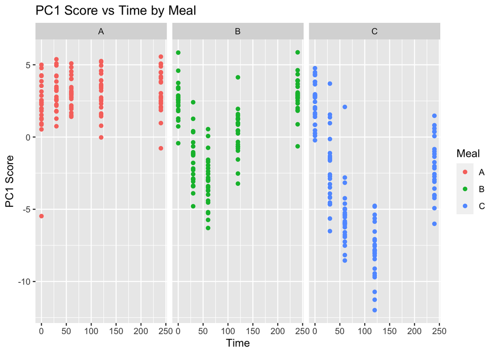

```r
# Make a plot of the first principal component score vs time, using a separate panel for each meal.
data1 <- read_csv("~/Desktop/metab-selected.csv")
PCA$x[,1]->PCA1

# Create a separate plot for each meal using facet_wrap
ggplot(data1, aes(x=Time, y=PCA1, color=Meal)) +
  geom_point() +
  facet_wrap(vars(Meal)) +
  xlab("Time") +
  ylab("PC1 Score") +
  ggtitle("PC1 Score vs Time by Meal")
```

## Lets investigate the outlier at time 0, meal A (the control meal).

```r
# Subset data to only include rows where Time is 0
d1<-data1 %>%
  mutate(PC1 = PCA1) %>%
  filter(Time == 0, Meal == "A")

which.min(d1$PC1)
```

```
## [1] 24
```

```r
d1$Participant[24]
```

```
## [1] "LD4227"
```

The outlier at time zero, Meal A (the control meal) corresponds LD4227.

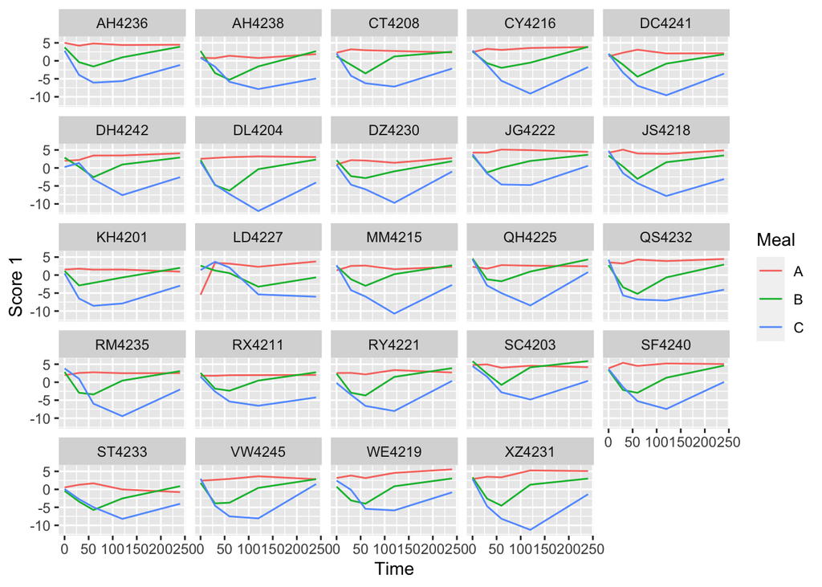

```r
ggplot(data1, aes(x = Time, y = PCA1, color = Meal)) +
  geom_line() +
  facet_wrap(vars(Participant)) +
  labs(x = "Time", y = "Score 1")
```

It is likely they are either…  
a) a weird observation; b) a weird day (the whole time course for that meal is unusual); or c) a weird participant.